# Python for Social Media (EDA)

## Facebook Metrics Refresher

### 1. Reach:

The number of unique people who saw your ad.

### 2. Impressions:

The total number of times an ad was displayed on your audience's screen.

### 3. Clicks (All):

The total number of clicks your ad received, including clicks on the like and share buttons.

### 4. Link Clicks:

The number of clicks on an ad link that leads to a specified destination.

### 5. CTR:

$\displaystyle \frac{\text{Total Clicks}}{\text{Total Impressions}} \times 100$

### 6. Conversions:

The number of times users completed the desired action.

### 7. Conversion Rate:

$\displaystyle \frac{\text{Number of Conversions}}{\text{Total Results}}$

### 8. CPM (Cost per Thousand Impressions):

$\displaystyle \frac{\text{Total Amount Spent}}{\text{Total Impressions}} \times 1000$

### 9. CPC (Cost per Link Click)

$\displaystyle \frac{\text{Total Amount Spent}}{\text{Total Link Clicks}}$

### 10. CPR (Cost per Result):

$\displaystyle \frac{\text{Total Amount Spent}}{\text{Total Results}}$

## Step 1: Examine the Dataset

```python
import pandas as pd
df = pd.read_csv('365DS Adsets.csv')
df.head()
```

|  | Reporting Starts | Reporting Ends | Ad Set Name | Amount Spent | Results | Result indicator | CPR | Reach | Impressions | Frequency | CPM | CPC | CTR (all) | Link Clicks | Landing Page Views |
| --- | --- | --- | --- | --- | --- | --- | --- | --- | --- | --- | --- | --- | --- | --- | --- |
| 0 | 20/5/2022 | 31/5/2022 | T1 - Cold - LLA - Promo May | 332.65 | 2 | actions:offsite_conversion.fb_pixel_purchase | 166.3250 | 6032 | 12594 | 2.087865 | 26.413371 | 2.294138 | 2.207400 | 145 | 89 |
| 1 | 20/5/2022 | 31/5/2022 | T1 - Cold - DT - Promo May | 915.00 | 15 | actions:offsite_conversion.fb_pixel_purchase | 61.0000 | 18900 | 42510 | 2.249206 | 21.524347 | 2.636888 | 1.587862 | 347 | 215 |
| 2 | 20/5/2022 | 31/5/2022 | T2 - Cold - LLA - Promo May | 327.77 | 4 | actions:offsite_conversion.fb_pixel_purchase | 81.9425 | 34743 | 61268 | 1.763463 | 5.349775 | 0.947312 | 1.237187 | 346 | 220 |
| 3 | 20/5/2022 | 31/5/2022 | T2 - Cold - DT - Promo May | 297.38 | 0 | NaN | NaN | 45001 | 65880 | 1.463967 | 4.513965 | 0.788806 | 1.220401 | 377 | 225 |
| 4 | 20/5/2022 | 31/5/2022 | T3 - Cold - LLA - Promo May | 291.45 | 4 | actions:offsite_conversion.fb_pixel_purchase | 72.8625 | 69040 | 147600 | 2.137891 | 1.974594 | 0.464092 | 1.115854 | 628 | 372 |

```python
df.info()
```

```
<class 'pandas.core.frame.DataFrame'>
RangeIndex: 13 entries, 0 to 12
Data columns (total 15 columns):
 #   Column              Non-Null Count  Dtype
---  ------              --------------  -----
 0   Reporting Starts    13 non-null     object
 1   Reporting Ends      13 non-null     object
 2   Ad Set Name         13 non-null     object
 3   Amount Spent        13 non-null     float64
 4   Results             13 non-null     int64
 5   Result indicator    11 non-null     object
 6   CPR                 11 non-null     float64
 7   Reach               13 non-null     int64
 8   Impressions         13 non-null     int64
 9   Frequency           13 non-null     float64
 10  CPM                 13 non-null     float64
 11  CPC                 13 non-null     float64
 12  CTR (all)           13 non-null     float64
 13  Link Clicks         13 non-null     int64
 14  Landing Page Views  13 non-null     int64
dtypes: float64(6), int64(5), object(4)
memory usage: 1.6+ KB
```

### Step 2: Campaign Highlights

```python
df[["Reach","Impressions","Link Clicks","Landing Page Views","Results","Amount Spent"]].sum()
```

```
Reach                  453534.00
Impressions           1136052.00
Link Clicks              5589.00
Landing Page Views       2985.00
Results                    83.00
Amount Spent             4362.12
dtype: float64
```

## Campaign Highlights

1. We reached around 450K unique people.
2. Approx 1.1 million impressions.
3. Each person saw the ad around 2.5 times.
4. Approx 5.6K link clicks and 2.9K landing page views.
5. Total of 83 results.
6. Spent 4,362 EUR.

### CPM (Cost per 1000 Impressions)

$\displaystyle \frac{\text{Total Amount Spent}}{\text{Impressions}} \times 1000$

```python
((df['Amount Spent']/df['Impressions'])*1000).mean()
```

```
6.552931634584926
```

```python
df.head()
```

|  | Reporting Starts | Reporting Ends | Ad Set Name | Amount Spent | Results | Result indicator | CPR | Reach | Impressions | Frequency | CPM | CPC | CTR (all) | Link Clicks | Landing Page Views |
| --- | --- | --- | --- | --- | --- | --- | --- | --- | --- | --- | --- | --- | --- | --- | --- |
| 0 | 20/5/2022 | 31/5/2022 | T1 - Cold - LLA - Promo May | 332.65 | 2 | actions:offsite_conversion.fb_pixel_purchase | 166.3250 | 6032 | 12594 | 2.087865 | 26.413371 | 2.294138 | 2.207400 | 145 | 89 |
| 1 | 20/5/2022 | 31/5/2022 | T1 - Cold - DT - Promo May | 915.00 | 15 | actions:offsite_conversion.fb_pixel_purchase | 61.0000 | 18900 | 42510 | 2.249206 | 21.524347 | 2.636888 | 1.587862 | 347 | 215 |
| 2 | 20/5/2022 | 31/5/2022 | T2 - Cold - LLA - Promo May | 327.77 | 4 | actions:offsite_conversion.fb_pixel_purchase | 81.9425 | 34743 | 61268 | 1.763463 | 5.349775 | 0.947312 | 1.237187 | 346 | 220 |
| 3 | 20/5/2022 | 31/5/2022 | T2 - Cold - DT - Promo May | 297.38 | 0 | NaN | NaN | 45001 | 65880 | 1.463967 | 4.513965 | 0.788806 | 1.220401 | 377 | 225 |
| 4 | 20/5/2022 | 31/5/2022 | T3 - Cold - LLA - Promo May | 291.45 | 4 | actions:offsite_conversion.fb_pixel_purchase | 72.8625 | 69040 | 147600 | 2.137891 | 1.974594 | 0.464092 | 1.115854 | 628 | 372 |

```python
df['CPM'].mean()
```

```
6.552931538461538
```

### Click-Through-Rate

$\displaystyle \frac{\text{Total Link Clicks}}{\text{Total Impressions}} \times 100$

```python
df.head(2)
```

|  | Reporting Starts | Reporting Ends | Ad Set Name | Amount Spent | Results | Result indicator | CPR | Reach | Impressions | Frequency | CPM | CPC | CTR (all) | Link Clicks | Landing Page Views |
| --- | --- | --- | --- | --- | --- | --- | --- | --- | --- | --- | --- | --- | --- | --- | --- |
| 0 | 20/5/2022 | 31/5/2022 | T1 - Cold - LLA - Promo May | 332.65 | 2 | actions:offsite_conversion.fb_pixel_purchase | 166.325 | 6032 | 12594 | 2.087865 | 26.413371 | 2.294138 | 2.207400 | 145 | 89 |
| 1 | 20/5/2022 | 31/5/2022 | T1 - Cold - DT - Promo May | 915.00 | 15 | actions:offsite_conversion.fb_pixel_purchase | 61.000 | 18900 | 42510 | 2.249206 | 21.524347 | 2.636888 | 1.587862 | 347 | 215 |

```python
((df['Link Clicks']/df['Impressions'])*100).mean()
```

```
0.5665608095472924
```

```python
df['CTR (all)'].mean()
```

```
1.2442086153846152
```

### Cost Per Result

$\displaystyle \frac{\text{Total Amount Spent}}{\text{Total Results}} $

```python
df.head(1)
```

|  | Reporting Starts | Reporting Ends | Ad Set Name | Amount Spent | Results | Result indicator | CPR | Reach | Impressions | Frequency | CPM | CPC | CTR (all) | Link Clicks | Landing Page Views |
| --- | --- | --- | --- | --- | --- | --- | --- | --- | --- | --- | --- | --- | --- | --- | --- |
| 0 | 20/5/2022 | 31/5/2022 | T1 - Cold - LLA - Promo May | 332.65 | 2 | actions:offsite_conversion.fb_pixel_purchase | 166.325 | 6032 | 12594 | 2.087865 | 26.413371 | 2.294138 | 2.2074 | 145 | 89 |

```python
(df['Amount Spent']/df['Results']).mean()
```

```
inf
```

```python
df_not_zero = df[df['Results']!=0]
```

```python
(df_not_zero['Amount Spent']/df_not_zero['Results']).mean()
```

```
63.75379220779221
```

```python
df['CPR'].mean()
```

```
63.75379220818183
```

## Step 3: Ad Set Overview

```python
df['Ad Set Name'].unique()
```

```
array(['T1 - Cold - LLA - Promo May', 'T1 - Cold - DT - Promo May',
       'T2 - Cold - LLA - Promo May', 'T2 - Cold - DT - Promo May',
       'T3 - Cold - LLA - Promo May', 'T3 - Cold - DT - Promo May',
       'T4 - Cold - DT - Promo May', 'T4 - Cold - LLA - Promo May',
       'Warm - CRSL', 'Warm - Videos', 'HOT - Last day',
       'HOT - Last chance & crsl', 'HOT - Discount'], dtype=object)
```

### Hot, Warm, and Cold Ad Sets

```python
def categorize_ad_set(ad_set_name):
    if 'Warm' in ad_set_name:
        return 'Warm'
    elif 'HOT' in ad_set_name:
        return 'Hot'
    else:
        return 'Cold'

df['Category'] = df['Ad Set Name'].apply(categorize_ad_set)
df.head()
```

|  | Reporting Starts | Reporting Ends | Ad Set Name | Amount Spent | Results | Result indicator | CPR | Reach | Impressions | Frequency | CPM | CPC | CTR (all) | Link Clicks | Landing Page Views | Category |
| --- | --- | --- | --- | --- | --- | --- | --- | --- | --- | --- | --- | --- | --- | --- | --- | --- |
| 0 | 20/5/2022 | 31/5/2022 | T1 - Cold - LLA - Promo May | 332.65 | 2 | actions:offsite_conversion.fb_pixel_purchase | 166.3250 | 6032 | 12594 | 2.087865 | 26.413371 | 2.294138 | 2.207400 | 145 | 89 | Cold |
| 1 | 20/5/2022 | 31/5/2022 | T1 - Cold - DT - Promo May | 915.00 | 15 | actions:offsite_conversion.fb_pixel_purchase | 61.0000 | 18900 | 42510 | 2.249206 | 21.524347 | 2.636888 | 1.587862 | 347 | 215 | Cold |
| 2 | 20/5/2022 | 31/5/2022 | T2 - Cold - LLA - Promo May | 327.77 | 4 | actions:offsite_conversion.fb_pixel_purchase | 81.9425 | 34743 | 61268 | 1.763463 | 5.349775 | 0.947312 | 1.237187 | 346 | 220 | Cold |
| 3 | 20/5/2022 | 31/5/2022 | T2 - Cold - DT - Promo May | 297.38 | 0 | NaN | NaN | 45001 | 65880 | 1.463967 | 4.513965 | 0.788806 | 1.220401 | 377 | 225 | Cold |
| 4 | 20/5/2022 | 31/5/2022 | T3 - Cold - LLA - Promo May | 291.45 | 4 | actions:offsite_conversion.fb_pixel_purchase | 72.8625 | 69040 | 147600 | 2.137891 | 1.974594 | 0.464092 | 1.115854 | 628 | 372 | Cold |

```python
results = df.groupby('Category').agg({'Reach':'mean','Impressions':'mean',
                                    'CTR (all)':'mean','Results':'mean',
                                    'CPR':'mean'})

results
```

| Category | Reach | Impressions | CTR (all) | Results | CPR |
| --- | --- | --- | --- | --- | --- |
| Cold | 44435.375000 | 79417.500000 | 1.370799 | 4.000000 | 80.352667 |
| Hot | 11195.666667 | 58889.666667 | 1.034126 | 10.333333 | 38.851667 |
| Warm | 32232.000000 | 162021.500000 | 1.052970 | 10.000000 | 51.310357 |

### Looalike vs Detailed Targeting

```python
df['Ad Set Name'].unique()
```

```
array(['T1 - Cold - LLA - Promo May', 'T1 - Cold - DT - Promo May',
       'T2 - Cold - LLA - Promo May', 'T2 - Cold - DT - Promo May',
       'T3 - Cold - LLA - Promo May', 'T3 - Cold - DT - Promo May',
       'T4 - Cold - DT - Promo May', 'T4 - Cold - LLA - Promo May',
       'Warm - CRSL', 'Warm - Videos', 'HOT - Last day',
       'HOT - Last chance & crsl', 'HOT - Discount'], dtype=object)
```

```python
def categorize_ad_set_2(ad_set_name):
    if('DT' in ad_set_name):
        return 'Detailed Targeting'
    elif('LLA' in ad_set_name):
        return 'Lookalike Audience'
    else:
        return 'Other'

df['Subcategory'] = df['Ad Set Name'].apply(categorize_ad_set_2)
```

```python
df_cold = df[df['Category']=='Cold']
```

```python
df_cold = df_cold.groupby('Subcategory').agg({'Reach':'mean','Impressions':'mean',
                                    'CTR (all)':'mean','Results':'mean',
                                    'CPR':'mean'})

df_cold
```

| Subcategory | Reach | Impressions | CTR (all) | Results | CPR |
| --- | --- | --- | --- | --- | --- |
| Detailed Targeting | 34033.25 | 53142.25 | 1.351996 | 4.25 | 53.2550 |
| Lookalike Audience | 54837.50 | 105692.75 | 1.389602 | 3.75 | 93.9015 |

```python
import matplotlib.pyplot as plt
import seaborn as sns
```

```python
df_transformed = df_cold.reset_index().melt('Subcategory')
df_transformed
```

|  | Subcategory | variable | value |
| --- | --- | --- | --- |
| 0 | Detailed Targeting | Reach | 34033.250000 |
| 1 | Lookalike Audience | Reach | 54837.500000 |
| 2 | Detailed Targeting | Impressions | 53142.250000 |
| 3 | Lookalike Audience | Impressions | 105692.750000 |
| 4 | Detailed Targeting | CTR (all) | 1.351996 |
| 5 | Lookalike Audience | CTR (all) | 1.389602 |
| 6 | Detailed Targeting | Results | 4.250000 |
| 7 | Lookalike Audience | Results | 3.750000 |
| 8 | Detailed Targeting | CPR | 53.255000 |
| 9 | Lookalike Audience | CPR | 93.901500 |

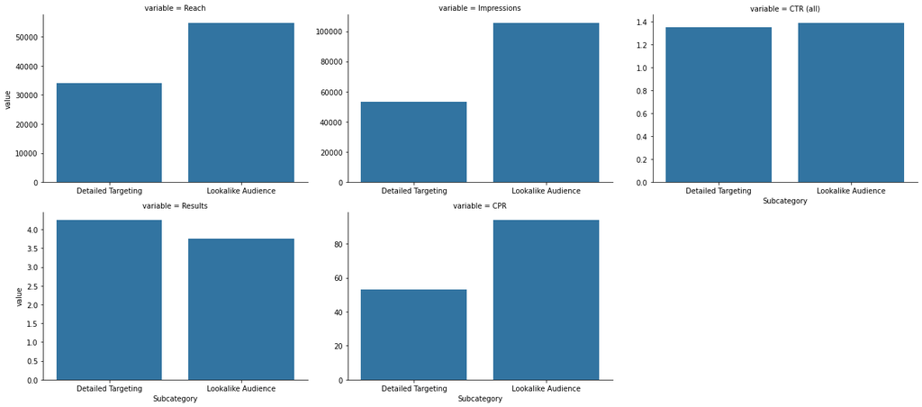

```python
viz = sns.FacetGrid(df_transformed, col='variable', col_wrap=3, sharex=False,
                   sharey=False, height=4, aspect=1.5)

viz.map(sns.barplot, 'Subcategory', 'value', order=df_cold.reset_index()['Subcategory'])

plt.show()
```

### Audience Performance Comparison: Detailed Targeting vs. Lookalike Audience

- Reach: Lookalike Audience achieved broader reach, suggesting stronger audience expansion potential.
- Impressions: Higher impressions for Lookalike Audience indicate greater visibility across placements.
- CTR (all): Click-through rates were nearly identical, showing both audiences drove similar engagement.
- Results: Detailed Targeting slightly outperformed in total results, hinting at higher action-oriented conversions.
- CPR (Cost Per Result): Lookalike Audience had a significantly higher cost per result, raising efficiency concerns